# Heart Disease Prediction

Amit Asghar, Manvir Sekhon, Lijuan Yang

October 12, 2018

# 1 Introduction

What is Heart Disease? Heart Disease is a group of conditions that affect the structure and functions of our heart. Build up of fatty material can cause arteries to narrow which prevents the heart from getting enough blood.

Using machine learning, our goal is to be able to predict if a patient has Heart Disease with a high degree of accuracy.

The data used is the Heart Disease Data Set from UCI Machine Learning Repository: https://archive.ics.uci.edu/ml/datasets/heart+Disease This data consists of 14 attributes. They come from 4 different locations. For this study, the dataset from Cleveland will be used.

The collection of the data is credited to the following individuals: Hungarian Institute of Cardiology. Budapest: Andras Janosi, M.D. University Hospital, Zurich, Switzerland: William Steinbrunn, M.D. University Hospital, Basel, Switzerland: Matthias Pfisterer, M.D. V.A. Medical Center, Long Beach and Cleveland Clinic Foundation:Robert Detrano, M.D., Ph.D.

# 2 Data Cleanup

Load libraries and data

```r
# Load packages
library('ggplot2') # visualization
library('caret')
library('dplyr')
library('Hmisc')

data=read.csv('cleveland_heart.csv', header = TRUE, na.strings = c("?",""))
```

Check data

```r
str(data)
```

```
## 'data.frame':    303 obs. of  14 variables:
##  $ AGE                    : num  63 67 67 37 41 56 62 57 63 53 ...
##  $ SEX                    : num  1 1 1 1 0 1 0 0 1 1 ...
##  $ CHEST_PAIN             : num  1 4 4 3 2 2 4 4 4 4 ...
##  $ REST_BP                : num  145 160 120 130 130 120 140 120 130 140 ...
##  $ CHOLESTEROL            : num  233 286 229 250 204 236 268 354 254 203 ...
##  $ FASTING_BLOOD_SUGAR    : num  1 0 0 0 0 0 0 0 0 1 ...
##  $ REST_ECG               : num  2 2 2 0 2 0 2 0 2 2 ...
##  $ MAX_HEART_RATE         : num  150 108 129 187 172 178 160 163 147 155 ...
##  $ EXERCISE_INDUCED_ANGINA: num  0 1 1 0 0 0 0 1 0 1 ...
##  $ OLDPEAK                : num  2.3 1.5 2.6 3.5 1.4 0.8 3.6 0.6 1.4 3.1 ...
##  $ SLOPE                  : num  3 2 2 3 1 1 3 1 2 3 ...
##  $ MAJOR_VESSELS          : num  0 3 2 0 0 0 2 0 1 0 ...
##  $ THAL                   : num  6 3 7 3 3 3 3 3 7 7 ...
##  $ HEART_DISEASE          : int  0 2 1 0 0 0 3 0 2 1 ...
```

We are going to consider any number 1 or greater for HEART_DISEASE as someone with heart disease so lets convert all numbers greater than 1 to 1.

```r
data$HEART_DISEASE[data$HEART_DISEASE > 0] <- 1
```

Change variables to correct data type

```r
names <- c('SEX','CHEST_PAIN','FASTING_BLOOD_SUGAR','REST_ECG','EXERCISE_INDUCED_ANGINA','SLOPE','MAJOR_VESSELS','THAL','HEART_DISEASE')
data[,names] <- lapply(data[,names] , factor)
str(data)
```

```
## 'data.frame':    303 obs. of  14 variables:
##  $ AGE                    : num  63 67 67 37 41 56 62 57 63 53 ...
##  $ SEX                    : Factor w/ 2 levels "0","1": 2 2 2 2 1 2 1 1 2 2 ...
##  $ CHEST_PAIN             : Factor w/ 4 levels "1","2","3","4": 1 4 4 3 2 2 4 4 4 4 ...
##  $ REST_BP                : num  145 160 120 130 130 120 140 120 130 140 ...
##  $ CHOLESTEROL            : num  233 286 229 250 204 236 268 354 254 203 ...
##  $ FASTING_BLOOD_SUGAR    : Factor w/ 2 levels "0","1": 2 1 1 1 1 1 1 1 1 2 ...
##  $ REST_ECG               : Factor w/ 3 levels "0","1","2": 3 3 3 1 3 1 3 1 3 3 ...
##  $ MAX_HEART_RATE         : num  150 108 129 187 172 178 160 163 147 155 ...
##  $ EXERCISE_INDUCED_ANGINA: Factor w/ 2 levels "0","1": 1 2 2 1 1 1 1 2 1 2 ...
##  $ OLDPEAK                : num  2.3 1.5 2.6 3.5 1.4 0.8 3.6 0.6 1.4 3.1 ...
##  $ SLOPE                  : Factor w/ 3 levels "1","2","3": 3 2 2 3 1 1 3 1 2 3 ...
##  $ MAJOR_VESSELS          : Factor w/ 4 levels "0","1","2","3": 1 4 3 1 1 1 3 1 2 1 ...
##  $ THAL                   : Factor w/ 3 levels "3","6","7": 2 1 3 1 1 1 1 1 3 3 ...
##  $ HEART_DISEASE          : Factor w/ 2 levels "0","1": 1 2 2 1 1 1 2 1 2 2 ...
```

Drop rows with missing values (only 6)

```r
sum(is.na(data))
```

```
## [1] 6
```

```r
data <- na.omit(data)
```

# 3 Visualize Data

## 3.1 Data Exploration

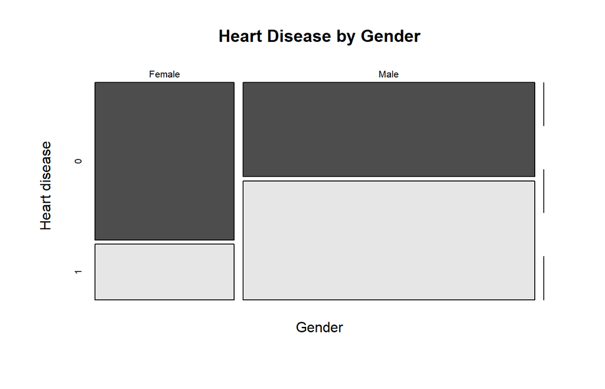

```r
levels(data$SEX) = c("Female","Male","")
mosaicplot(data$SEX ~ data$HEART_DISEASE, main="Heart Disease by Gender", color=TRUE,
           xlab="Gender", ylab="Heart disease")
```

Seems like a much higher percentage of men have heart disease

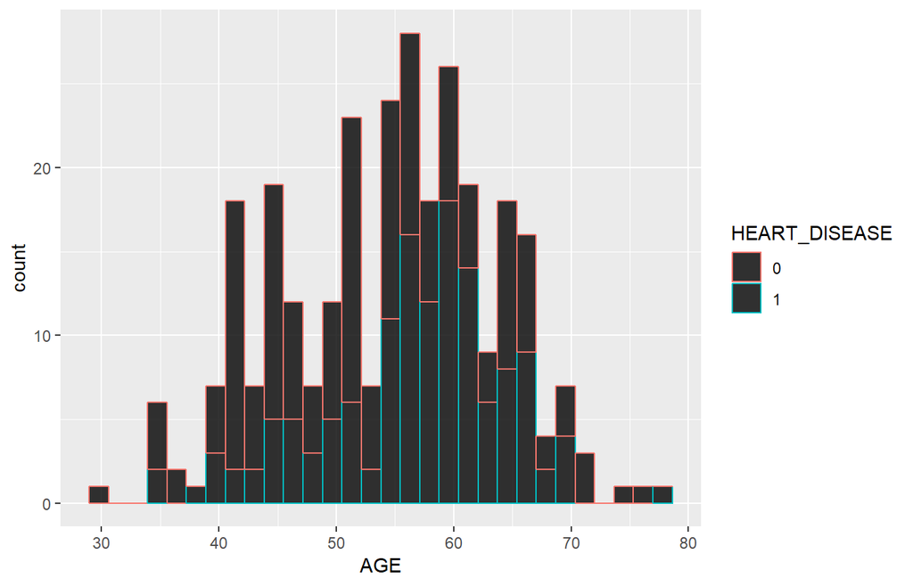

```r
ggplot(data, aes(x=AGE, color=HEART_DISEASE)) +
  geom_histogram(fill="black", alpha=0.8)
```

Around age 60, there seems to be a higher percentage of people with Heart disease

## 3.2 Correlation analysis

```r
d2 <- data[,c(4,5,8)] # a data frame that only contains the numerical attributes
cm <- rcorr(as.matrix(d2)) # the correlation matrix with significance values
cm # this outputs the correlation matrix (r), n (which is the number of observations)
```

```
##                REST_BP CHOLESTEROL MAX_HEART_RATE
## REST_BP           1.00        0.13          -0.05
## CHOLESTEROL       0.13        1.00           0.00
## MAX_HEART_RATE   -0.05        0.00           1.00
##
## n= 297
##
##
## P
##                REST_BP CHOLESTEROL MAX_HEART_RATE
## REST_BP                0.0234      0.3991
## CHOLESTEROL    0.0234              0.9990
## MAX_HEART_RATE 0.3991  0.9990
```

```r
cm$P # this outputs the p values
```

```
##                   REST_BP CHOLESTEROL MAX_HEART_RATE
## REST_BP                NA  0.02338135      0.3990907
## CHOLESTEROL    0.02338135          NA      0.9989790
## MAX_HEART_RATE 0.39909075  0.99897898             NA
```

We can say with 95% confidence than Resting Blood Pressure (rest_bp) and Cholesterol have significant correlation. This is because the p-value for rest_bp and cholesterol is 0.0234 which is less than 0.05 (5%).

# 4 Outlier Analysis

## 4.1 Boxplots

The boxplots for the four numerical attributes will now be plotted

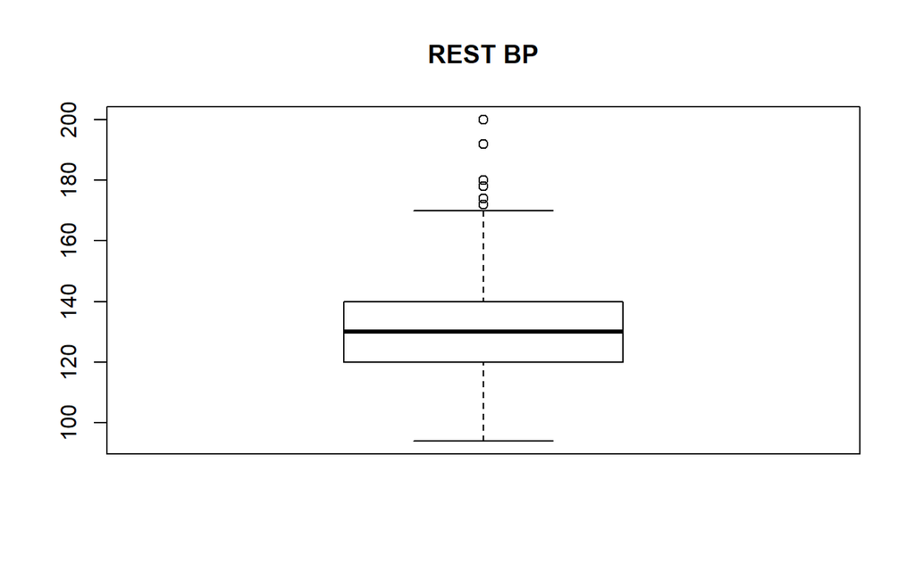

```r
boxplot(data$REST_BP, main="REST BP")
```

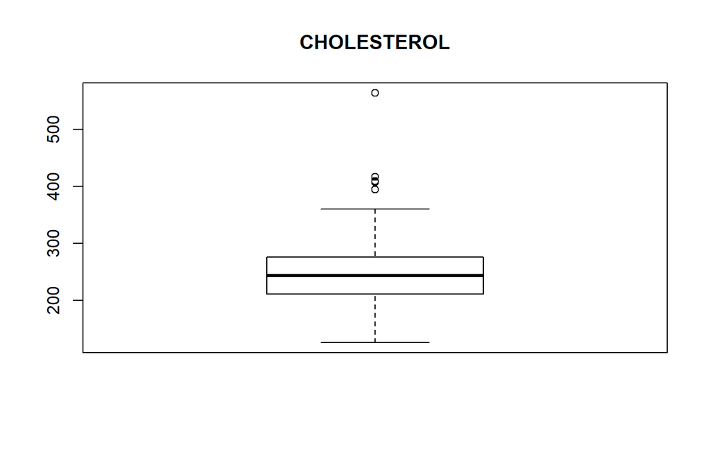

```r
boxplot(data$CHOLESTEROL, main="CHOLESTEROL")
```

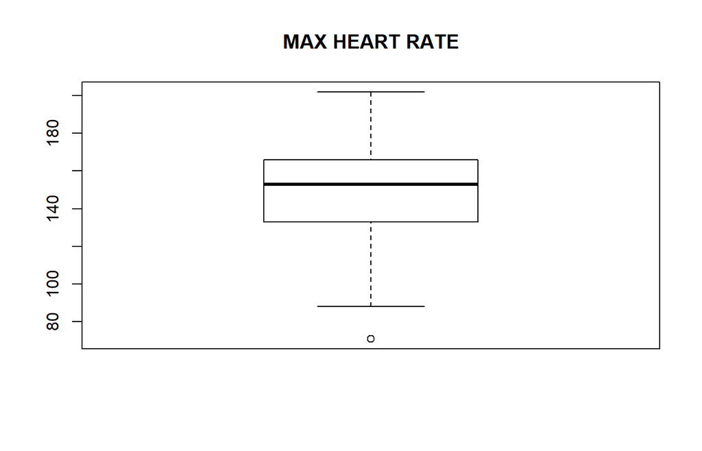

```r
boxplot(data$MAX_HEART_RATE, main="MAX HEART RATE")
```

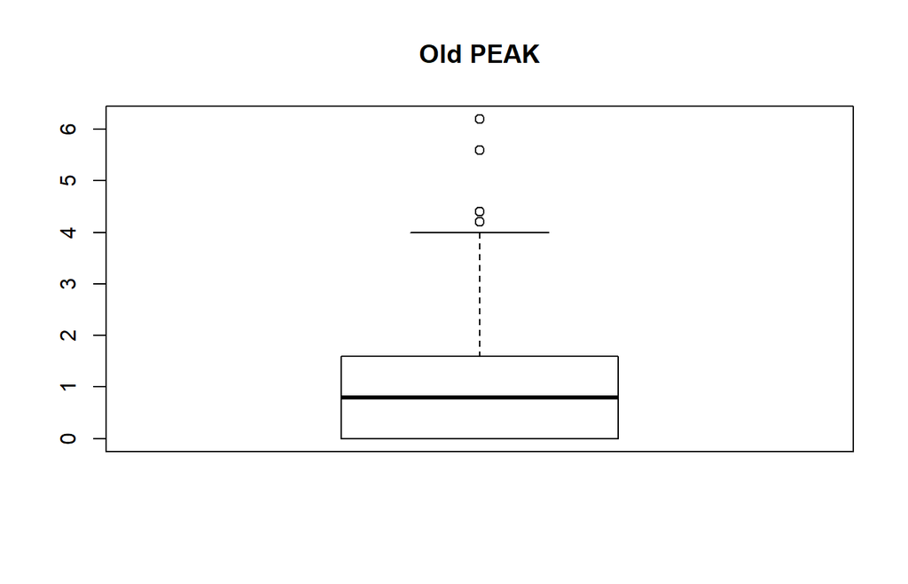

```r
boxplot(data$OLDPEAK, main= "Old PEAK")
```

# 5 Prediction

## 5.1 Split into training & test sets

Data will be split into 70% Train and 30% Test. The ratio of Heart Disease is preserved in both Train and Test Data.

```r
inTrain <- createDataPartition(data$HEART_DISEASE, times = 1, p = 0.7, list = FALSE)
trainData<-data[inTrain,]
testData<-data[-inTrain,]
```

## 5.2 Create Model

Create a model using logistic regression.

```r
set.seed(11)
model <- glm(HEART_DISEASE ~.,family=binomial(link='logit'),data=trainData)
```

## 5.3 Model Analysis

```r
summary(model)
```

```
##
## Call:
## glm(formula = HEART_DISEASE ~ ., family = binomial(link = "logit"),
##     data = trainData)
##
## Deviance Residuals:
##      Min        1Q    Median        3Q       Max
## -2.92055  -0.40551  -0.08785   0.26694   2.97286
##
## Coefficients:
##                           Estimate Std. Error z value Pr(>|z|)
## (Intercept)              -4.597797   3.377709  -1.361  0.17344
## AGE                      -0.035003   0.033501  -1.045  0.29611
## SEXMale                   1.733640   0.747155   2.320  0.02032 *
## CHEST_PAIN2               1.692401   1.022366   1.655  0.09785 .
## CHEST_PAIN3               0.018281   0.889900   0.021  0.98361
## CHEST_PAIN4               2.697495   0.854305   3.158  0.00159 **
## REST_BP                   0.021392   0.015391   1.390  0.16455
## CHOLESTEROL               0.005202   0.005150   1.010  0.31249
## FASTING_BLOOD_SUGAR1      0.224846   0.768120   0.293  0.76973
## REST_ECG1                 2.008971   3.402691   0.590  0.55492
## REST_ECG2                 0.872257   0.528723   1.650  0.09900 .
## MAX_HEART_RATE           -0.025685   0.015004  -1.712  0.08692 .
## EXERCISE_INDUCED_ANGINA1  0.263754   0.602143   0.438  0.66137
## OLDPEAK                   0.419159   0.309170   1.356  0.17518
## SLOPE2                    0.767116   0.598741   1.281  0.20012
## SLOPE3                    0.519490   1.097958   0.473  0.63611
## MAJOR_VESSELS1            1.875115   0.684945   2.738  0.00619 **
## MAJOR_VESSELS2            2.762041   0.969732   2.848  0.00440 **
## MAJOR_VESSELS3            2.961914   1.163882   2.545  0.01093 *
## THAL6                    -0.377701   1.261981  -0.299  0.76472
## THAL7                     2.258359   0.567400   3.980 6.89e-05 ***
## ---
## Signif. codes:  0 '***' 0.001 '**' 0.01 '*' 0.05 '.' 0.1 ' ' 1
##
## (Dispersion parameter for binomial family taken to be 1)
##
##     Null deviance: 287.12  on 207  degrees of freedom
## Residual deviance: 118.71  on 187  degrees of freedom
## AIC: 160.71
##
## Number of Fisher Scoring iterations: 6
```

```r
anova(model,test="Chisq")
```

```
## Analysis of Deviance Table
##
## Model: binomial, link: logit
##
## Response: HEART_DISEASE
##
## Terms added sequentially (first to last)
##
##
##                         Df Deviance Resid. Df Resid. Dev  Pr(>Chi)
## NULL                                      207     287.12
## AGE                      1    4.566       206     282.55 0.0326135 *
## SEX                      1   23.606       205     258.94 1.182e-06 ***
## CHEST_PAIN               3   55.803       202     203.14 4.628e-12 ***
## REST_BP                  1    3.481       201     199.66 0.0620872 .
## CHOLESTEROL              1    1.921       200     197.74 0.1657021
## FASTING_BLOOD_SUGAR      1    0.609       199     197.13 0.4350999
## REST_ECG                 2    2.772       197     194.36 0.2501013
## MAX_HEART_RATE           1   20.979       196     173.38 4.643e-06 ***
## EXERCISE_INDUCED_ANGINA  1    3.693       195     169.69 0.0546410 .
## OLDPEAK                  1    7.354       194     162.33 0.0066930 **
## SLOPE                    2    2.383       192     159.95 0.3037348
## MAJOR_VESSELS            3   20.645       189     139.31 0.0001248 ***
## THAL                     2   20.596       187     118.71 3.369e-05 ***
## ---
## Signif. codes:  0 '***' 0.001 '**' 0.01 '*' 0.05 '.' 0.1 ' ' 1
```

We can say with 95% confidence that the attributes (for which the p-values are less than 0.05) have a significant effect one the model.

## 5.4 Prediction

```r
predicted <- plogis(predict(model, testData))
```

## 5.5 Check prediction accuracy

```r
fitted.results <- ifelse(predicted > 0.5,1,0)
misClasificError <- mean(fitted.results != testData$HEART_DISEASE)
print(paste('Accuracy',1-misClasificError))
```

```
## [1] "Accuracy 0.820224719101124"
```

The model achieved accuracy of between 80-86%

## 5.6 Confusion Matrix

```r
confMat <- confusionMatrix(factor(fitted.results, levels = 0:1),factor(testData$HEART_DISEASE, levels = 0:1))
confMat
```

```
## Confusion Matrix and Statistics
##
##           Reference
## Prediction  0  1
##          0 46 14
##          1  2 27
##
##                Accuracy : 0.8202
##                  95% CI : (0.7245, 0.8936)
##     No Information Rate : 0.5393
##     P-Value [Acc > NIR] : 2.567e-08
##
##                   Kappa : 0.6303
##  Mcnemar's Test P-Value : 0.00596
##
##             Sensitivity : 0.9583
##             Specificity : 0.6585
##          Pos Pred Value : 0.7667
##          Neg Pred Value : 0.9310
##              Prevalence : 0.5393
##          Detection Rate : 0.5169
##    Detection Prevalence : 0.6742
##       Balanced Accuracy : 0.8084
##
##        'Positive' Class : 0
##
```

# 6 Conclusion

A dataset of 300 patients containing 14 attributes is used to develop a Logistic Regression model to detect Heart Disease.

With the accuracy achieved, the model may be used by assist Doctor but should not be the only source to determine diagnosis.

However, this study suggests that the accuracy can be further improved with the following techniques: 1. Collect more patient data. With only 300 subjects, we achieved a relatively accurate model. It is likely that even higher accuracy can be achieved with a larger data set. 2. Try other classifiers like Neural Networks, Support Vector Machines, Decision Trees etc. and compare results.

It is recommended that the model be deployed to software used by Doctors. It can be used to quickly identify patients with Heart Disease and bring the list of patients with probable Heart Disease to the Doctors attention for further review. This will result in time and cost savings and better overall patient health in the long term.

## 6.1 Deployment

The model has been deployed to an interactive Web App: https://asghar.shinyapps.io/heartapp/